# Machine Learning Project

Kannimangalam Ashok

01/06/2020

## Overview

Using devices such as Jawbone Up, Nike FuelBand, and Fitbit it is now possible to collect a large amount of data about personal activity relatively inexpensively. These type of devices are part of the quantified self movement – a group of enthusiasts who take measurements about themselves regularly to improve their health, to find patterns in their behavior, or because they are tech geeks. One thing that people regularly do is quantify how much of a particular activity they do, but they rarely quantify how well they do it. In this project, We will be using data from accelerometers on the belt, forearm, arm, and dumbell of 6 participants. They were asked to perform barbell lifts correctly and incorrectly in 5 different ways.The goal of this project is to build a model and use it to predict the manner in which they did the exercise.

The following packages are used

```r
        library(caret)
```

```r
        library(ggplot2)
        set.seed(12345)
```

## Data used

```r
        urltrain <- "https://d396qusza40orc.cloudfront.net/predmachlearn/pml-training.csv"
        urltest <- "https://d396qusza40orc.cloudfront.net/predmachlearn/pml-testing.csv"

        modelData <- read.csv(urltrain,header = TRUE)
        submitData <- read.csv(urltest,header = TRUE)
```

## Exploratory data analysis and data cleaning

```r
        str(modelData)
```

```
## 'data.frame':    19622 obs. of  160 variables:
##  $ X                       : int  1 2 3 4 5 6 7 8 9 10 ...
##  $ user_name               : Factor w/ 6 levels "adelmo","carlitos",..: 2 2 2 2 2 2 2 2 2 2 ...
##  $ raw_timestamp_part_1    : int  1323084231 1323084231 1323084231 1323084232 1323084232 1323084232 1323084232 1323084232 1323084232 1323084232 ...
##  $ raw_timestamp_part_2    : int  788290 808298 820366 120339 196328 304277 368296 440390 484323 484434 ...
##  $ cvtd_timestamp          : Factor w/ 20 levels "02/12/2011 13:32",..: 9 9 9 9 9 9 9 9 9 9 ...
##  $ new_window              : Factor w/ 2 levels "no","yes": 1 1 1 1 1 1 1 1 1 1 ...
##  $ num_window              : int  11 11 11 12 12 12 12 12 12 12 ...
##  $ roll_belt               : num  1.41 1.41 1.42 1.48 1.48 1.45 1.42 1.42 1.43 1.45 ...
##  $ pitch_belt              : num  8.07 8.07 8.07 8.05 8.07 8.06 8.09 8.13 8.16 8.17 ...
##  $ yaw_belt                : num  -94.4 -94.4 -94.4 -94.4 -94.4 -94.4 -94.4 -94.4 -94.4 -94.4 ...
##  $ total_accel_belt        : int  3 3 3 3 3 3 3 3 3 3 ...
##  $ kurtosis_roll_belt      : Factor w/ 397 levels "","-0.016850",..: 1 1 1 1 1 1 1 1 1 1 ...
##  $ kurtosis_picth_belt     : Factor w/ 317 levels "","-0.021887",..: 1 1 1 1 1 1 1 1 1 1 ...
##  $ kurtosis_yaw_belt       : Factor w/ 2 levels "","#DIV/0!": 1 1 1 1 1 1 1 1 1 1 ...
```

[output cut: 86 more lines]

We check for any missing data

```r
        naData <- sapply(modelData,is.na)
        nastat <- apply(naData,2,sum)
        nacols <- which(nastat > 0,arr.ind = TRUE)
```

We find that there are 67 columns with NA. we remove those columns in modelData and submitData

```r
        cleanModelData <- modelData[,-nacols]
        cleanSubmitData <- submitData[,-nacols]
```

We also remove the index and date stamp columns as they don’t contribute to the prediction. ie we remove the first 5 columns. We also remove columns that has near zero variance.

```r
        cleanModelData <- cleanModelData[,-c(1:5)]
        cleanSubmitData <- cleanSubmitData[,-c(1:5)]
        NZV <- nearZeroVar(cleanModelData)
        cleanModelData <- cleanModelData[, -NZV]
        cleanSubmitData  <- cleanSubmitData[, -NZV]
        dim(cleanModelData)
```

```
## [1] 19622    54
```

```r
        dim(cleanSubmitData)
```

```
## [1] 20 54
```

## Prediction Model

We split the cleanModelData into training and test set

```r
        inTrain <- createDataPartition(cleanModelData$classe, p= 0.7,list = FALSE)
        training <- cleanModelData[inTrain,]
        testing <- cleanModelData[-inTrain,]
        dim(training) ; dim(testing)
```

```
## [1] 13737    54
```

```
## [1] 5885   54
```

We fit the training data using Random Forest as Ramdom Forest produces models for high accuracy prediction. We will be controlling the training using trControl parameter for cross validation.

```r
        memory.limit(size = 10000) #Random forest is memory intensive
```

```
## [1] 10000
```

```r
        tr_Control <- trainControl(method="cv", number=3, verboseIter=FALSE)
        rffit <- train(classe ~ ., data=training, method="rf",
                          trControl=tr_Control)
        rffit$finalModel
```

```
##
## Call:
##  randomForest(x = x, y = y, mtry = param$mtry)
##                Type of random forest: classification
##                      Number of trees: 500
## No. of variables tried at each split: 27
##
##         OOB estimate of  error rate: 0.19%
## Confusion matrix:
##      A    B    C    D    E  class.error
## A 3905    0    0    0    1 0.0002560164
## B    6 2648    3    1    0 0.0037622272
## C    0    5 2391    0    0 0.0020868114
## D    0    0    8 2244    0 0.0035523979
## E    0    0    0    2 2523 0.0007920792
```

The out-of-bag error estimate is 0.19% which is quite low.Now we validate the model with the testing data to see the accuracy of the model.

```r
        predModel <- predict(rffit,testing)
        CM <- confusionMatrix(predModel,testing$classe)
        CM
```

```
## Confusion Matrix and Statistics
##
##           Reference
## Prediction    A    B    C    D    E
##          A 1674    1    0    0    0
##          B    0 1138    1    0    0
##          C    0    0 1025    2    0
##          D    0    0    0  961    0
##          E    0    0    0    1 1082
##
## Overall Statistics
##
##                Accuracy : 0.9992
##                  95% CI : (0.998, 0.9997)
##     No Information Rate : 0.2845
##     P-Value [Acc > NIR] : < 2.2e-16
##
##                   Kappa : 0.9989
##
##  Mcnemar's Test P-Value : NA
##
## Statistics by Class:
##
##                      Class: A Class: B Class: C Class: D Class: E
## Sensitivity            1.0000   0.9991   0.9990   0.9969   1.0000
## Specificity            0.9998   0.9998   0.9996   1.0000   0.9998
## Pos Pred Value         0.9994   0.9991   0.9981   1.0000   0.9991
## Neg Pred Value         1.0000   0.9998   0.9998   0.9994   1.0000
## Prevalence             0.2845   0.1935   0.1743   0.1638   0.1839
## Detection Rate         0.2845   0.1934   0.1742   0.1633   0.1839
## Detection Prevalence   0.2846   0.1935   0.1745   0.1633   0.1840
## Balanced Accuracy      0.9999   0.9995   0.9993   0.9984   0.9999
```

The model accuracy is at 99.9%. We will therefore choose this model.

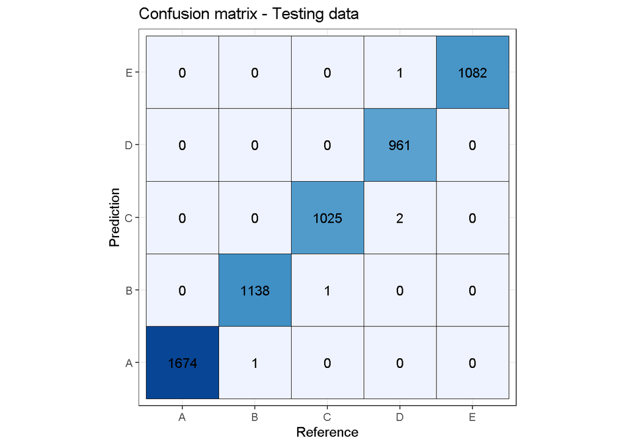

```r
        CMdf <- as.data.frame(CM$table)
        g <- ggplot(CMdf,aes(x= Reference, y = Prediction, fill = Freq))
        g + geom_tile(colour = "black") + theme_bw() + coord_equal() + scale_fill_distiller(palette =  "Blues" , direction = +1)  +
  guides(fill=F) +
  labs(title = "Confusion matrix - Testing data") +
  geom_text(aes(label= Freq), color="black")
```

## Prediction

Now we predict the outcome for the 20 cases in the cleanSubmitData.

```r
        result <- predict(rffit,cleanSubmitData)
        result
```

```
##  [1] B A B A A E D B A A B C B A E E A B B B
## Levels: A B C D E
```